# About this website and course

Author

Affiliations

Jelmer Poelstra

[CFAES Bioinformatics Core, Ohio State University](https://go.osu.edu/bioinformatics-core)

[Dept. of Plant Pathology, Ohio State University](https://plantpath.osu.edu)

Published

August 1, 2026

Page last modified

August 24, 2026

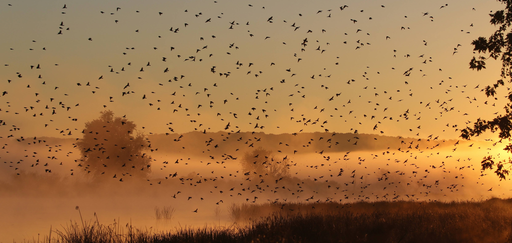

### Overview

This is the GitHub website for the course **Practical Computing Skills for Omics Data** (PLNTPTH 5006), a 3-credit course taught at Ohio State University during the Fall semester of 2026.

The course is taught by Jelmer Poelstra from the [CFAES Bioinformatics Core](https://go.osu.edu/bioinformatics-core) and [Department of Plant Pathology](https://plantpath.osu.edu) , with TA Kelsey Starr from the Department of Plant Pathology.

### Course description

Omics data is everywhere, but can you actually analyze it? This course will teach you the skills to do so: using the Unix shell, writing shell and R scripts, and running jobs on the Ohio Supercomputer Center. You will also learn how to improve the reproducibility of your research using best-practice project organization, documentation, and version control. No prior coding experience required.

### Main topics taught

- **Reproducibility** — project documentation with Markdown, file organization, data and management and sharing
- **Unix shell** — basics, scripting, running command-line programs
- **HPC / Supercomputer usage** — basics, software, and running Slurm batch jobs at [OSC](https://osc.edu)
- **Version control** — with Git and GitHub
- **Running pipelines** — using Nextflow/nf-core pipelines
- **R** — Basics, data wrangling & visualization, Quarto, and specifics to omics data
- **Omics data and analysis basics** — with a focus on high-throughput sequencing data
- **AI** — Using generative and agentic AI to help with coding

### CarmenCanvas website

If you are a student in this course, you should also refer to [its CarmenCanvas site](https://osu.instructure.com/courses/213814) .

### Simple Syllabus

[Simple Syllabus for this course](https://osu.simplesyllabus.com/doc/4ldq70j6l/Autumn-2026-PLNTPTH-5006-33285-Practical-Computing-Skills-for-Omics-Data?mode=view) .